# South Dade Conveyance System Environmental Information

Point of Contact: Paul Julian (paul.julian@dep.state.fl.us)

*Please note this analysis is for informational purposes only and subject to change.*

# Hydrologic Information

Provided in this section are period of record (POR) discharge data and associated metrics of available data in the South Florida Water Management Districts [DBHYDRO](http://my.sfwmd.gov/dbhydroplsql/show_dbkey_info.main_menu). All structure DBKEYs used to construct these discharge time-series can be found in this [file](https://github.com/SwampThingPaul/SouthDade_WQ/blob/master/DataInventory_existing.xlsx?raw=true).

[interactive chart not shown]

Interactive map of structures monitored within the South Dade Conveyance System. Within the current period of record, no data is available for S328 (D-Detention Area) or G737 (Frog Pond Detention Area) to assess annual conditions.

Below is a series of plots for each structure with accessible/available data. Only positive flows were used in this analysis. Reverse flow has been observed at some structures The three plots are flow-duration curves using daily data for the entire POR for any given structure (left), daily discharge volume (middle) and total discharge volume based on the Florida Water Year (right). The lower flow-duration limit (20% Exceedance) for each structure has been identified where applicable. All hydrologic data is presented in m<sup>3</sup> d<sup>-1</sup> or m<sup>3</sup> WY<sup>-1</sup>, to convert from m<sup>3</sup> to acre-feet, multiply values by 0.000810714.

## S331

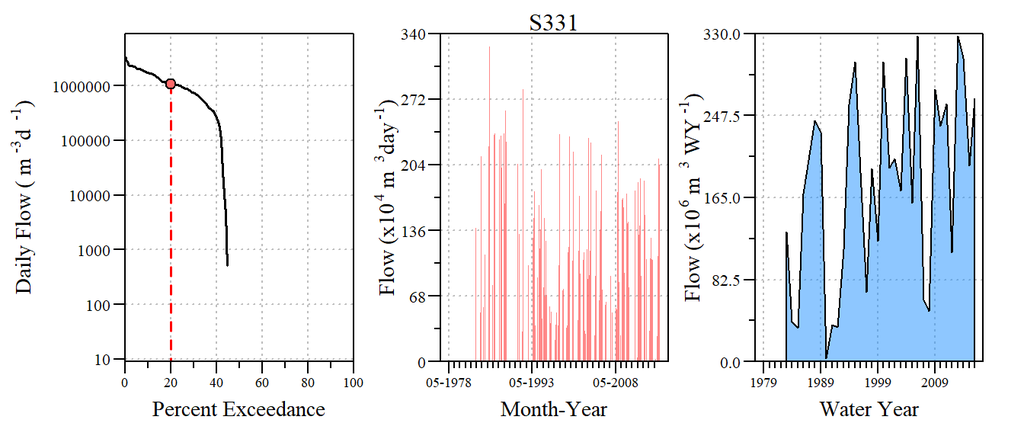

Daily Discharge Data Summary for the Period of Record (Units:m<sup>3</sup> d<sup>-1</sup>)

```
##    Min. 1st Qu.  Median    Mean 3rd Qu.    Max.
##       0       0       0  501989  947927 3387241
```

Daily Discharge Data Summary for the last 10-WYs (May 2005 - April 2016; Units:m<sup>3</sup> d<sup>-1</sup>)

```
##    Min. 1st Qu.  Median    Mean 3rd Qu.    Max.
##       0       0   69189  601338 1069272 2993122
```

Water Year Discharge Data Summary for the Period of Record (Units:m<sup>3</sup> WY<sup>-1</sup>)

```
##      Min.   1st Qu.    Median      Mean   3rd Qu.      Max.
##   3247248 110676392 194872336 180317405 259369218 327449753
```

Water Year Discharge Data Summary for the last 10-WYs (2006-2016; Units:m<sup>3</sup> d<sup>-1</sup>)

```
##      Min.   1st Qu.    Median      Mean   3rd Qu.      Max.
##  50562343 153779872 259628183 219652473 289775981 327449753
```

## S173

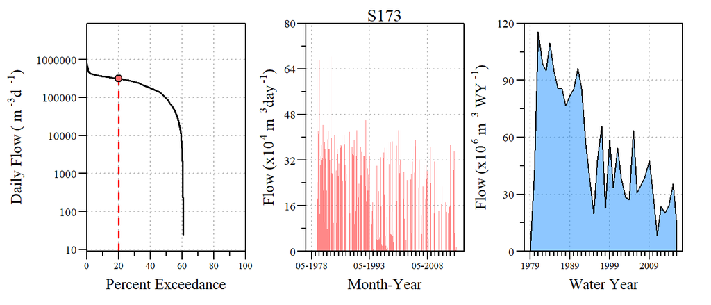

Daily Discharge Data Summary for the Period of Record (Units:m<sup>3</sup> d<sup>-1</sup>)

```
##    Min. 1st Qu.  Median    Mean 3rd Qu.    Max.
##       0       0   94646  145324  291161  779285
```

Daily Discharge Data Summary for the last 10-WYs (May 2005 - April 2016; Units:m<sup>3</sup> d<sup>-1</sup>)

```
##    Min. 1st Qu.  Median    Mean 3rd Qu.    Max.
##       0       0       0   76666  152000  608489
```

Water Year Discharge Data Summary for the Period of Record (Units:m<sup>3</sup> WY<sup>-1</sup>)

```
##      Min.   1st Qu.    Median      Mean   3rd Qu.      Max.
##         0  28877271  45165163  53081330  84540073 115510577
```

Water Year Discharge Data Summary for the last 10-WYs (2006-2016; Units:m<sup>3</sup> d<sup>-1</sup>)

```
##     Min.  1st Qu.   Median     Mean  3rd Qu.     Max.
##  8378656 21754794 30377863 28004133 35418025 47617199
```

## S357

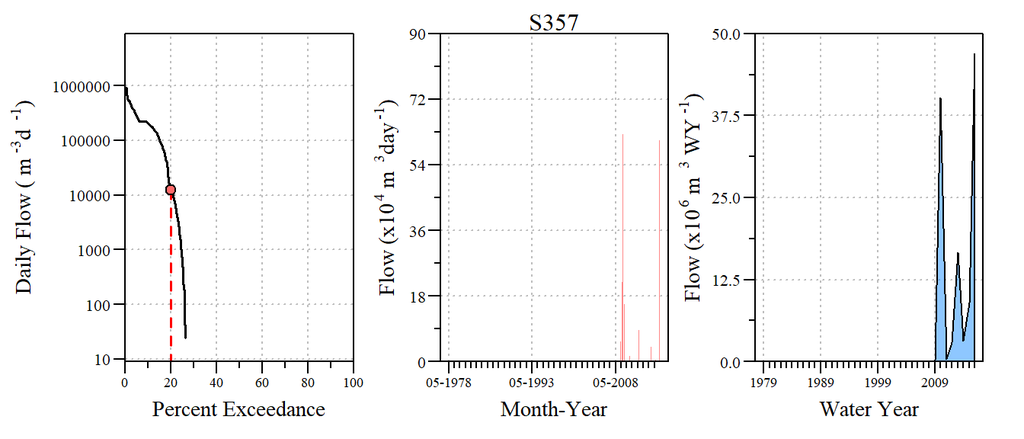

Daily Discharge Data Summary for the Period of Record (Units:m<sup>3</sup> d<sup>-1</sup>)

```
##     Min.  1st Qu.   Median     Mean  3rd Qu.     Max.
##      0.0      0.0      0.0  46379.3    538.2 938654.9
```

Daily Discharge Data Summary for the last 10-WYs (May 2005 - April 2016; Units:m<sup>3</sup> d<sup>-1</sup>)

```
##     Min.  1st Qu.   Median     Mean  3rd Qu.     Max.
##      0.0      0.0      0.0  46379.3    538.2 938654.9
```

Water Year Discharge Data Summary for the Period of Record (Units:m<sup>3</sup> WY<sup>-1</sup>)

```
##     Min.  1st Qu.   Median     Mean  3rd Qu.     Max.
##   302544  2242511  6065732 14928331 22525264 46919337
```

Water Year Discharge Data Summary for the last 10-WYs (2006-2016; Units:m<sup>3</sup> d<sup>-1</sup>)

```
##     Min.  1st Qu.   Median     Mean  3rd Qu.     Max.
##   302544  2242511  6065732 14928331 22525264 46919337
```

## S332B

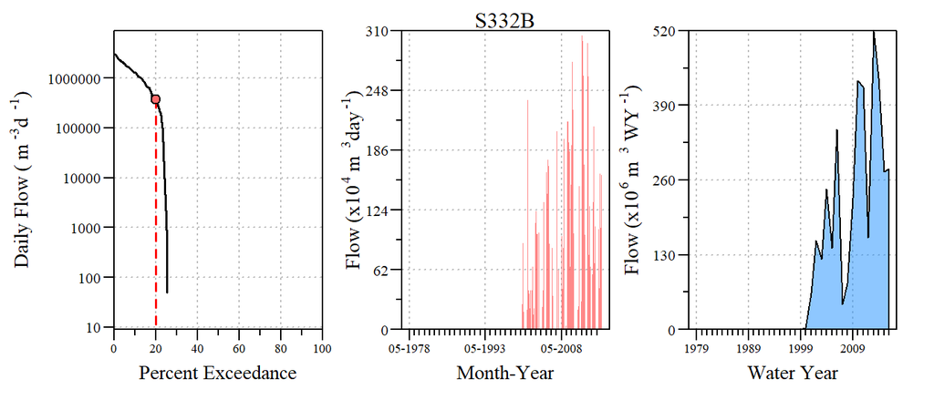

Daily Discharge Data Summary for the Period of Record (Units:m<sup>3</sup> d<sup>-1</sup>)

```
##    Min. 1st Qu.  Median    Mean 3rd Qu.    Max.
##       0       0       0  284678    1370 3094312
```

Daily Discharge Data Summary for the last 10-WYs (May 2005 - April 2016; Units:m<sup>3</sup> d<sup>-1</sup>)

```
##    Min. 1st Qu.  Median    Mean 3rd Qu.    Max.
##       0       0  405105  802283 1558043 3094312
```

Water Year Discharge Data Summary for the Period of Record (Units:m<sup>3</sup> WY<sup>-1</sup>)

```
##      Min.   1st Qu.    Median      Mean   3rd Qu.      Max.
##         0         0         0 103982527 158670775 518418558
```

Water Year Discharge Data Summary for the last 10-WYs (2006-2016; Units:m<sup>3</sup> d<sup>-1</sup>)

```
##      Min.   1st Qu.    Median      Mean   3rd Qu.      Max.
##  44058477 194084011 278737612 293052251 427132646 518418558
```

## S332C

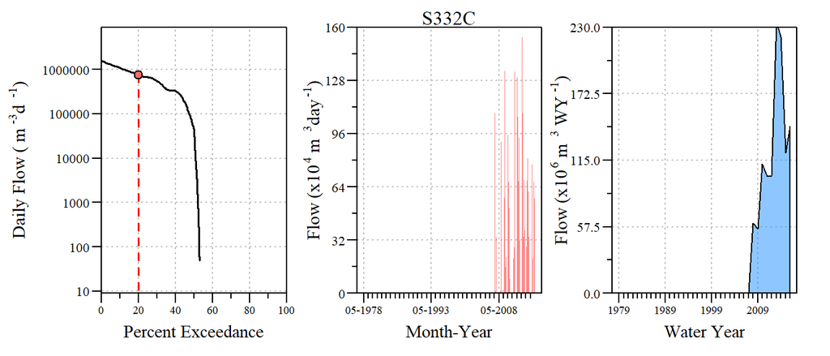

Daily Discharge Data Summary for the Period of Record (Units:m<sup>3</sup> d<sup>-1</sup>)

```
##    Min. 1st Qu.  Median    Mean 3rd Qu.    Max.
##       0       0   42766  347184  675941 1559793
```

Daily Discharge Data Summary for the last 10-WYs (May 2005 - April 2016; Units:m<sup>3</sup> d<sup>-1</sup>)

```
##    Min. 1st Qu.  Median    Mean 3rd Qu.    Max.
##       0       0   42766  347184  675941 1559793
```

Water Year Discharge Data Summary for the Period of Record (Units:m<sup>3</sup> WY<sup>-1</sup>)

```
##      Min.   1st Qu.    Median      Mean   3rd Qu.      Max.
##    638729  70783572 106714376 115369295 138468825 234780056
```

Water Year Discharge Data Summary for the last 10-WYs (2006-2016; Units:m<sup>3</sup> d<sup>-1</sup>)

```
##      Min.   1st Qu.    Median      Mean   3rd Qu.      Max.
##    638729  70783572 106714376 115369295 138468825 234780056
```

## S174

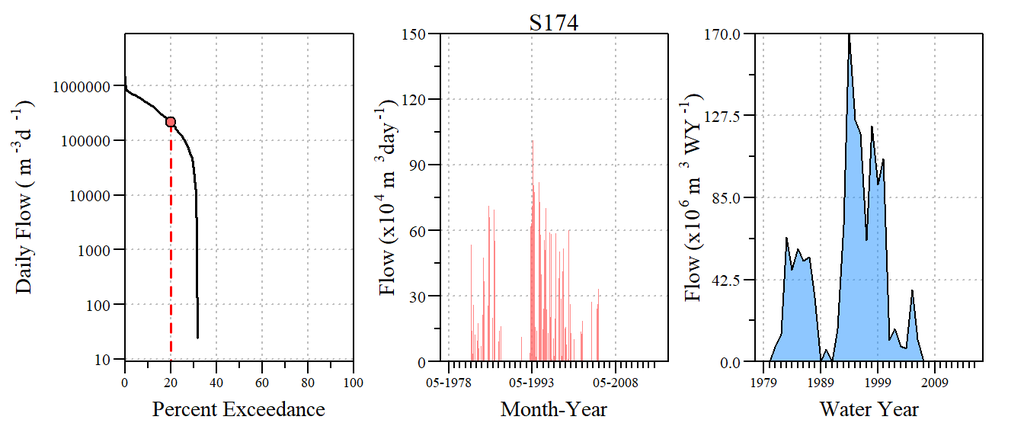

Daily Discharge Data Summary for the Period of Record (Units:m<sup>3</sup> d<sup>-1</sup>)

```
##    Min. 1st Qu.  Median    Mean 3rd Qu.    Max.
##       0       0       0  110756  117950 1506726
```

Water Year Discharge Data Summary for the Period of Record (Units:m<sup>3</sup> WY<sup>-1</sup>)

```
##      Min.   1st Qu.    Median      Mean   3rd Qu.      Max.
##         0    101778  17215849  39835348  62970786 171300504
```

Water Year Discharge Data Summary for the last 10-WYs (2006-2016; Units:m<sup>3</sup> d<sup>-1</sup>)

```
##     Min.  1st Qu.   Median     Mean  3rd Qu.     Max.
##        0        0       37  1892087      973 11351177
```

## S332DX1

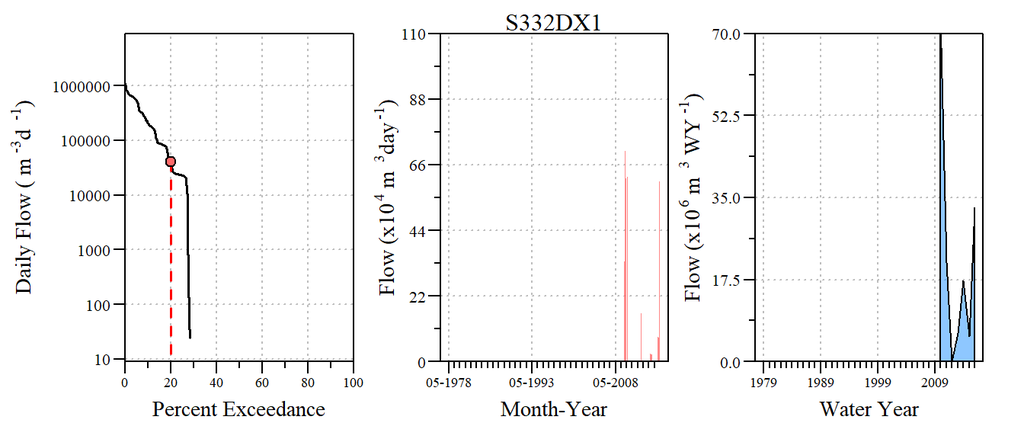

Daily Discharge Data Summary for the Period of Record (Units:m<sup>3</sup> d<sup>-1</sup>)

```
##    Min. 1st Qu.  Median    Mean 3rd Qu.    Max.
##       0       0       0   62577   23047 1094502
```

Daily Discharge Data Summary for the last 10-WYs (May 2005 - April 2016; Units:m<sup>3</sup> d<sup>-1</sup>)

```
##    Min. 1st Qu.  Median    Mean 3rd Qu.    Max.
##       0       0       0   62577   23047 1094502
```

Water Year Discharge Data Summary for the Period of Record (Units:m<sup>3</sup> WY<sup>-1</sup>)

```
##     Min.  1st Qu.   Median     Mean  3rd Qu.     Max.
##      391  5736814 17269307 22339823 27042049 73551339
```

Water Year Discharge Data Summary for the last 10-WYs (2006-2016; Units:m<sup>3</sup> d<sup>-1</sup>)

```
##     Min.  1st Qu.   Median     Mean  3rd Qu.     Max.
##      391  5736814 17269307 22339823 27042049 73551339
```

## S332D

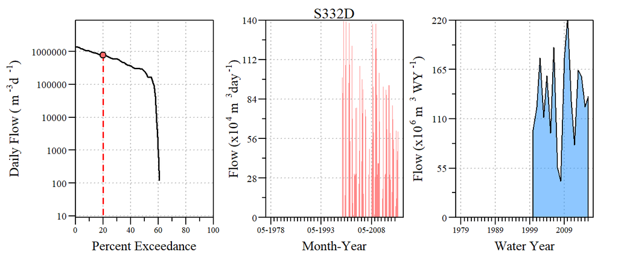

Daily Discharge Data Summary for the Period of Record (Units:m<sup>3</sup> d<sup>-1</sup>)

```
##    Min. 1st Qu.  Median    Mean 3rd Qu.    Max.
##       0       0  250456  365980  650521 1398392
```

Water Year Discharge Data Summary for the Period of Record (Units:m<sup>3</sup> WY<sup>-1</sup>)

```
##      Min.   1st Qu.    Median      Mean   3rd Qu.      Max.
##  40511255  97467050 129619246 131709864 164223013 223503622
```

## S176

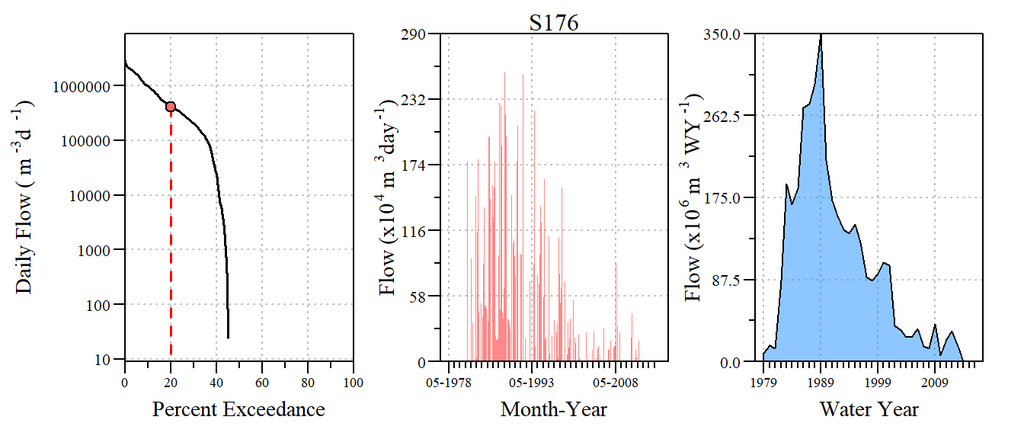

Daily Discharge Data Summary for the Period of Record (Units:m<sup>3</sup> d<sup>-1</sup>)

```
##    Min. 1st Qu.  Median    Mean 3rd Qu.    Max.
##       0       0       0  269770  305810 2903479
```

Daily Discharge Data Summary for the last 10-WYs (May 2005 - April 2016; Units:m<sup>3</sup> d<sup>-1</sup>)

```
##    Min. 1st Qu.  Median    Mean 3rd Qu.    Max.
##       0       0       0   46365       0 1870435
```

Water Year Discharge Data Summary for the Period of Record (Units:m<sup>3</sup> WY<sup>-1</sup>)

```
##      Min.   1st Qu.    Median      Mean   3rd Qu.      Max.
##         0  19112267  86111249  98537143 152927459 350523816
```

Water Year Discharge Data Summary for the last 10-WYs (2006-2016; Units:m<sup>3</sup> d<sup>-1</sup>)

```
##     Min.  1st Qu.   Median     Mean  3rd Qu.     Max.
##        0  3500787 16335179 16935712 28502853 40239488
```

## S200

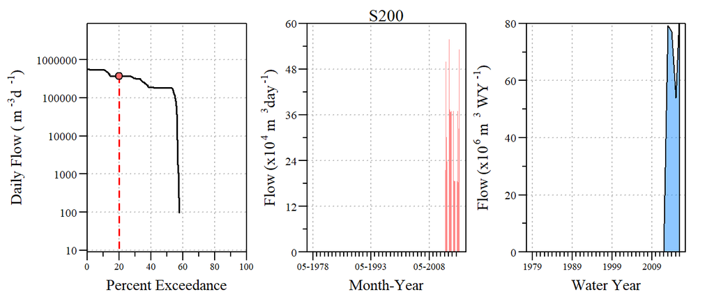

Daily Discharge Data Summary for the Period of Record (Units:m<sup>3</sup> d<sup>-1</sup>)

```
##    Min. 1st Qu.  Median    Mean 3rd Qu.    Max.
##       0       0  185989  187713  368663  562518
```

Daily Discharge Data Summary for the last 10-WYs (May 2005 - April 2016; Units:m<sup>3</sup> d<sup>-1</sup>)

```
##    Min. 1st Qu.  Median    Mean 3rd Qu.    Max.
##       0       0  185989  187713  368663  562518
```

Water Year Discharge Data Summary for the Period of Record (Units:m<sup>3</sup> WY<sup>-1</sup>)

```
##     Min.  1st Qu.   Median     Mean  3rd Qu.     Max.
##        0 53929620 77217245 59016892 79166460 84771135
```

Water Year Discharge Data Summary for the last 10-WYs (2006-2016; Units:m<sup>3</sup> d<sup>-1</sup>)

```
##     Min.  1st Qu.   Median     Mean  3rd Qu.     Max.
##        0 53929620 77217245 59016892 79166460 84771135
```

## S332

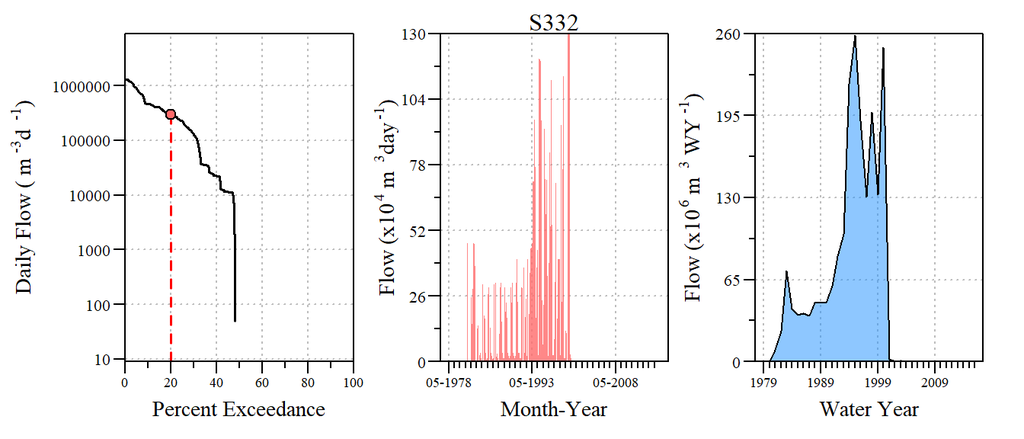

Daily Discharge Data Summary for the Period of Record (Units:m<sup>3</sup> d<sup>-1</sup>)

```
##    Min. 1st Qu.  Median    Mean 3rd Qu.    Max.
##       0       0       0  155156  229245 1319098
```

Daily Discharge Data Summary for the last 10-WYs (May 2005 - April 2016; Units:m<sup>3</sup> d<sup>-1</sup>)

```
##     Min.  1st Qu.   Median     Mean  3rd Qu.     Max.
##    0.000    0.000    0.000    2.244    0.000 4403.844
```

Water Year Discharge Data Summary for the Period of Record (Units:m<sup>3</sup> WY<sup>-1</sup>)

```
##      Min.   1st Qu.    Median      Mean   3rd Qu.      Max.
##         0        37  30470197  56222654  74940275 258589560
```

Water Year Discharge Data Summary for the last 10-WYs (2006-2016; Units:m<sup>3</sup> d<sup>-1</sup>)

```
##    Min. 1st Qu.  Median    Mean 3rd Qu.    Max.
##    0.00    0.00    0.00  793.78   48.93 5822.86
```

## S175

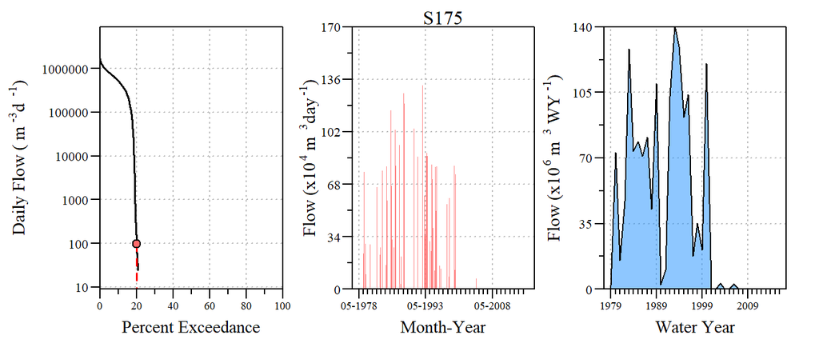

Daily Discharge Data Summary for the Period of Record (Units:m<sup>3</sup> d<sup>-1</sup>)

```
##    Min. 1st Qu.  Median    Mean 3rd Qu.    Max.
##       0       0       0  108317       0 1695235
```

Daily Discharge Data Summary for the last 10-WYs (May 2005 - April 2016; Units:m<sup>3</sup> d<sup>-1</sup>)

```
##      Min.   1st Qu.    Median      Mean   3rd Qu.      Max.
##       0.0       0.0       0.0     659.9       0.0 1657239.9
```

Water Year Discharge Data Summary for the Period of Record (Units:m<sup>3</sup> WY<sup>-1</sup>)

```
##      Min.   1st Qu.    Median      Mean   3rd Qu.      Max.
##       220     11713  12681089  39564266  77431034 140444212
```

Water Year Discharge Data Summary for the last 10-WYs (2006-2016; Units:m<sup>3</sup> d<sup>-1</sup>)

```
##      Min.   1st Qu.    Median      Mean   3rd Qu.      Max.
##     220.2    1602.5    3400.7  241054.9   15474.6 2554743.3
```

## S199

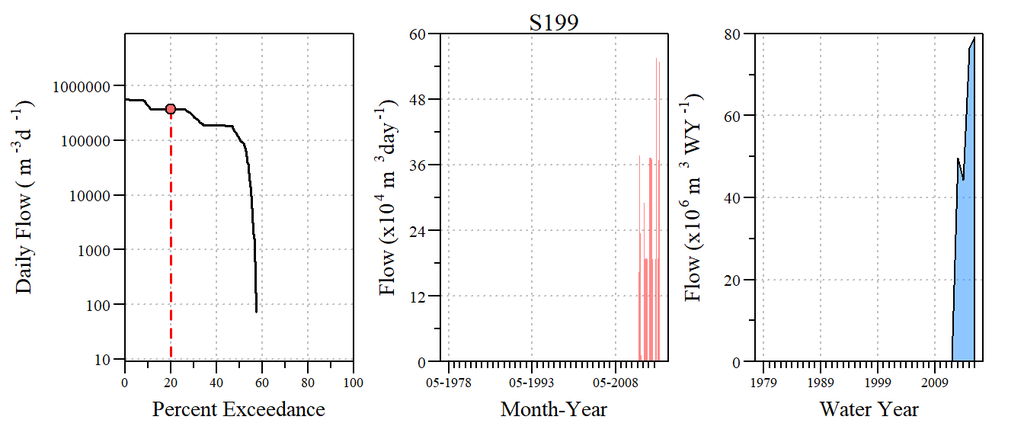

Daily Discharge Data Summary for the Period of Record (Units:m<sup>3</sup> d<sup>-1</sup>)

```
##    Min. 1st Qu.  Median    Mean 3rd Qu.    Max.
##       0       0  108738  167708  368559  561686
```

Daily Discharge Data Summary for the last 10-WYs (May 2005 - April 2016; Units:m<sup>3</sup> d<sup>-1</sup>)

```
##    Min. 1st Qu.  Median    Mean 3rd Qu.    Max.
##       0       0  108738  167708  368559  561686
```

Water Year Discharge Data Summary for the Period of Record (Units:m<sup>3</sup> WY<sup>-1</sup>)

```
##     Min.  1st Qu.   Median     Mean  3rd Qu.     Max.
##        0 44204171 49671470 49909845 76430817 79242769
```

Water Year Discharge Data Summary for the last 10-WYs (2006-2016; Units:m<sup>3</sup> d<sup>-1</sup>)

```
##     Min.  1st Qu.   Median     Mean  3rd Qu.     Max.
##        0 44204171 49671470 49909845 76430817 79242769
```

## S177

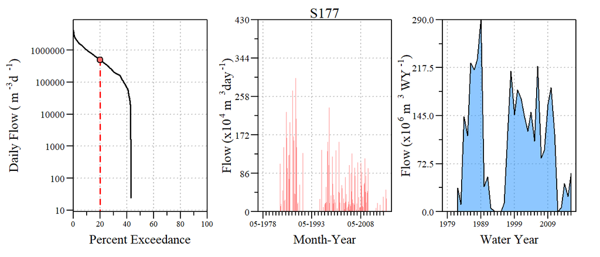

Daily Discharge Data Summary for the Period of Record (Units:m<sup>3</sup> d<sup>-1</sup>)

```
##    Min. 1st Qu.  Median    Mean 3rd Qu.    Max.
##       0       0       0  293577  340796 4319584
```

Daily Discharge Data Summary for the last 10-WYs (May 2005 - April 2016; Units:m<sup>3</sup> d<sup>-1</sup>)

```
##    Min. 1st Qu.  Median    Mean 3rd Qu.    Max.
##       0       0       0  246394  344723 4319584
```

Water Year Discharge Data Summary for the Period of Record (Units:m<sup>3</sup> WY<sup>-1</sup>)

```
##      Min.   1st Qu.    Median      Mean   3rd Qu.      Max.
##         0  29310004 114468138 106325365 166221954 290952138
```

Water Year Discharge Data Summary for the last 10-WYs (2006-2016; Units:m<sup>3</sup> d<sup>-1</sup>)

```
##      Min.   1st Qu.    Median      Mean   3rd Qu.      Max.
##         0  32656326  81143028  90000948 139774351 220041515
```

## S178

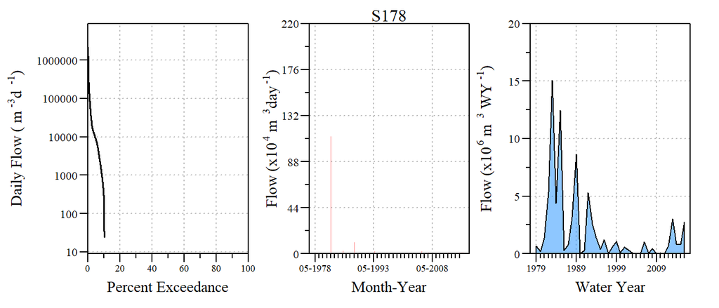

Daily Discharge Data Summary for the Period of Record (Units:m<sup>3</sup> d<sup>-1</sup>)

```
##    Min. 1st Qu.  Median    Mean 3rd Qu.    Max.
##       0       0       0    5475       0 2152330
```

Daily Discharge Data Summary for the last 10-WYs (May 2005 - April 2016; Units:m<sup>3</sup> d<sup>-1</sup>)

```
##     Min.  1st Qu.   Median     Mean  3rd Qu.     Max.
##      0.0      0.0      0.0   2402.1    458.7 286470.0
```

Water Year Discharge Data Summary for the Period of Record (Units:m<sup>3</sup> WY<sup>-1</sup>)

```
##     Min.  1st Qu.   Median     Mean  3rd Qu.     Max.
##        0   128458   649200  1999768  2264769 15085123
```

Water Year Discharge Data Summary for the last 10-WYs (2006-2016; Units:m<sup>3</sup> d<sup>-1</sup>)

```
##    Min. 1st Qu.  Median    Mean 3rd Qu.    Max.
##       0   62608  634912  877430  943719 3028303
```

## S18C

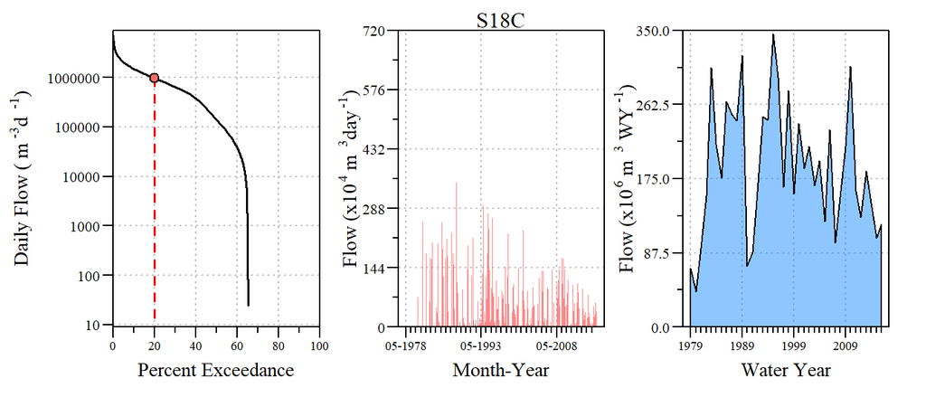

Daily Discharge Data Summary for the Period of Record (Units:m<sup>3</sup> d<sup>-1</sup>)

```
##    Min. 1st Qu.  Median    Mean 3rd Qu.    Max.
##       0       0  140311  516650  802478 7192945
```

Daily Discharge Data Summary for the last 10-WYs (May 2005 - April 2016; Units:m<sup>3</sup> d<sup>-1</sup>)

```
##    Min. 1st Qu.  Median    Mean 3rd Qu.    Max.
##       0       0  265075  461127  761431 5362781
```

Water Year Discharge Data Summary for the Period of Record (Units:m<sup>3</sup> WY<sup>-1</sup>)

```
##      Min.   1st Qu.    Median      Mean   3rd Qu.      Max.
##  41675288 133582118 179911205 188713128 244154170 345587254
```

Water Year Discharge Data Summary for the last 10-WYs (2006-2016; Units:m<sup>3</sup> d<sup>-1</sup>)

```
##      Min.   1st Qu.    Median      Mean   3rd Qu.      Max.
##  99119690 125303136 153422316 168437033 198789127 307577481
```

## S197

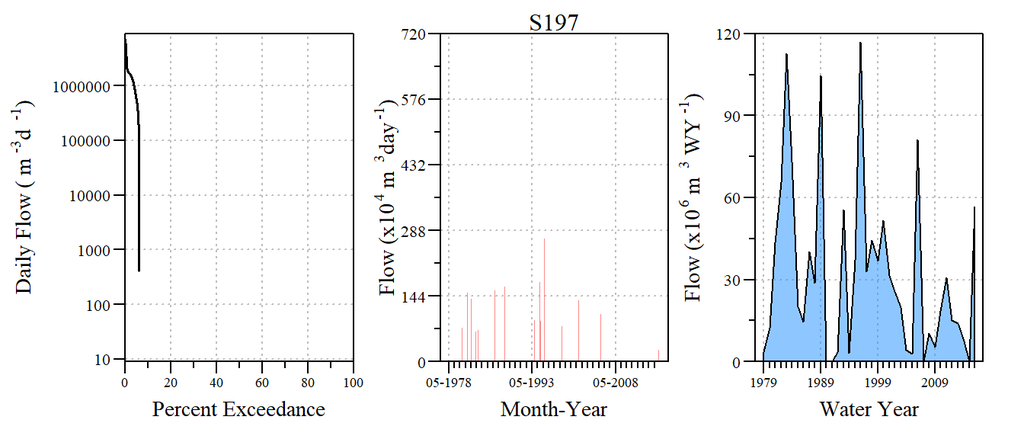

Daily Discharge Data Summary for the Period of Record (Units:m<sup>3</sup> d<sup>-1</sup>)

```
##    Min. 1st Qu.  Median    Mean 3rd Qu.    Max.
##       0       0       0   88291       0 7198523
```

Daily Discharge Data Summary for the last 10-WYs (May 2005 - April 2016; Units:m<sup>3</sup> d<sup>-1</sup>)

```
##    Min. 1st Qu.  Median    Mean 3rd Qu.    Max.
##       0       0       0   59803       0 6839096
```

Water Year Discharge Data Summary for the Period of Record (Units:m<sup>3</sup> WY<sup>-1</sup>)

```
##      Min.   1st Qu.    Median      Mean   3rd Qu.      Max.
##         0   6093348  22890227  32249537  44205811 116987113
```

Water Year Discharge Data Summary for the last 10-WYs (2006-2016; Units:m<sup>3</sup> d<sup>-1</sup>)

```
##     Min.  1st Qu.   Median     Mean  3rd Qu.     Max.
##        0  6863795 13941738 21844312 24606882 81209281
```

# Water Quality Information

Provided in this section are period of record water quality data and summaries of data located in the South Florida Water Management Districts [DBHYDRO](http://my.sfwmd.gov/dbhydroplsql/show_dbkey_info.main_menu). All structure-water quality monitoring location pairings used to construct these water quality time-series can be found in this [file](https://github.com/SwampThingPaul/SouthDade_WQ/blob/master/DataInventory_existing.xlsx?raw=true).

Below are a series of plots for each structure with accessible/available data. The data are presented both as individual grab samples (i.e. raw data) and annual flow-weighted mean concentrations based on the Florida Water Year (May 1 - April 30). Water quality data were screened for fatal qualifiers and paired with flow data for each structure with available data. Flow-weighted mean concentrations were calcualted for structures with greater than three samples per year using only positive flow. Similar to the plots above for discharge data, three plots were developed to represent each structure and the associated water quality (total phosphorus). The three plots include (1) the top left plot displaying a percent exceedance curve for all data (solid line) and only flowing conditions (dashed line) based on grab sample (weekly, biweekly or monthly depending on structure); (2) top right plot displays raw grab sample total phosphorus concentration with points color coded relative to flowing conditions (blue: flowing, red: not flowing); (3) bottom plot displays annual flow-weighted mean concentrations and weighted-standard error (FWM $\pm$ SE<sub>wtd</sub>). All concentrations are expressed as $\mu$g L<sup>-1</sup> (i.e. parts-per-billion).

## S331

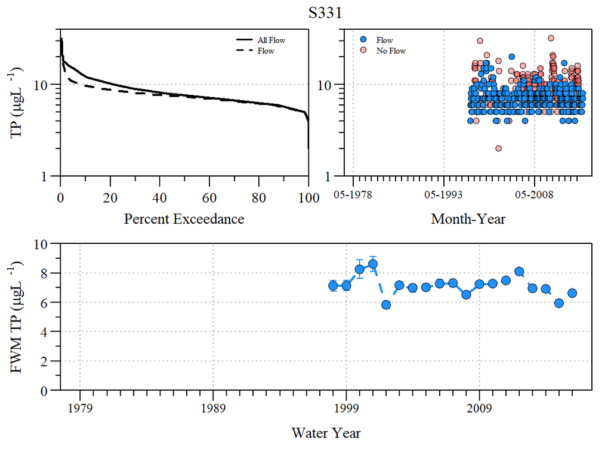

## S173

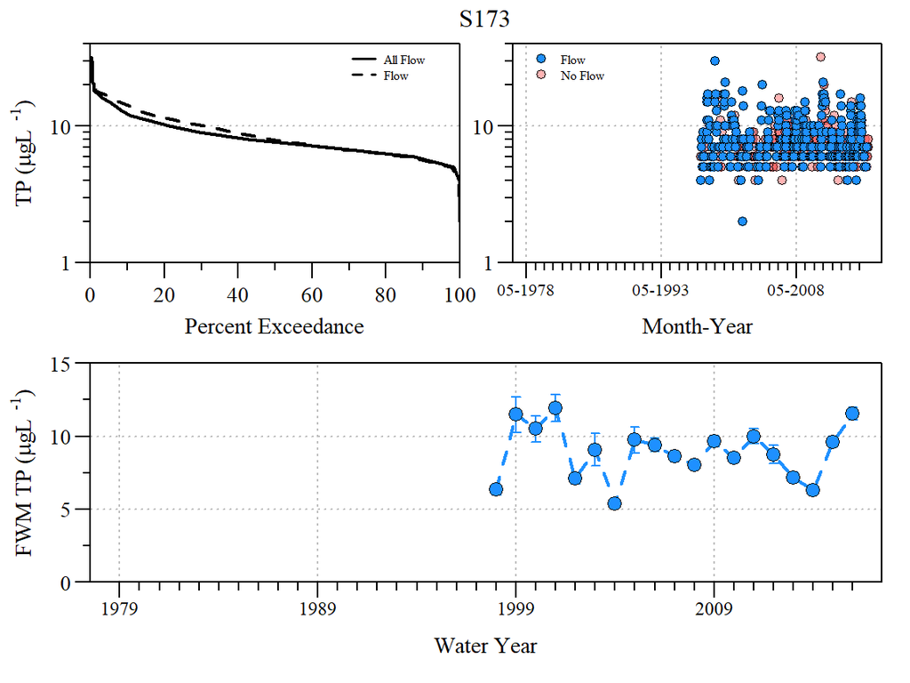

## S357

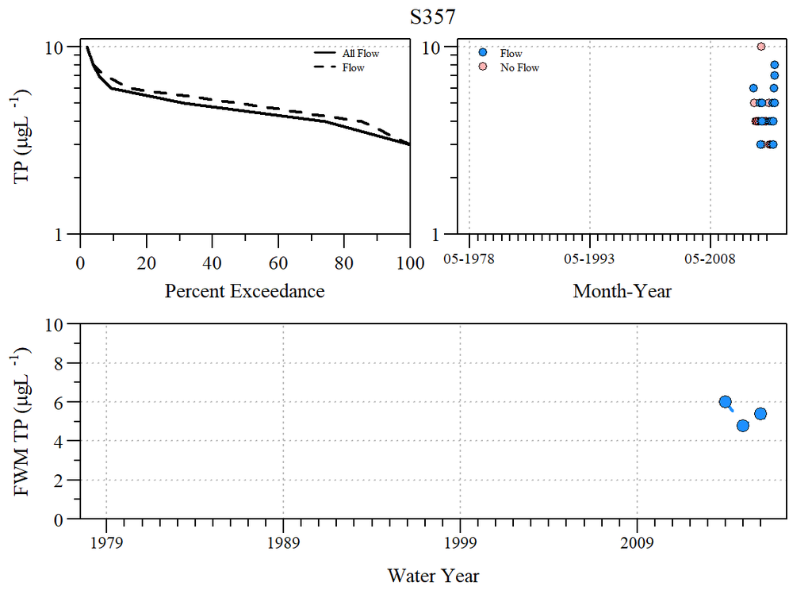

## S332B

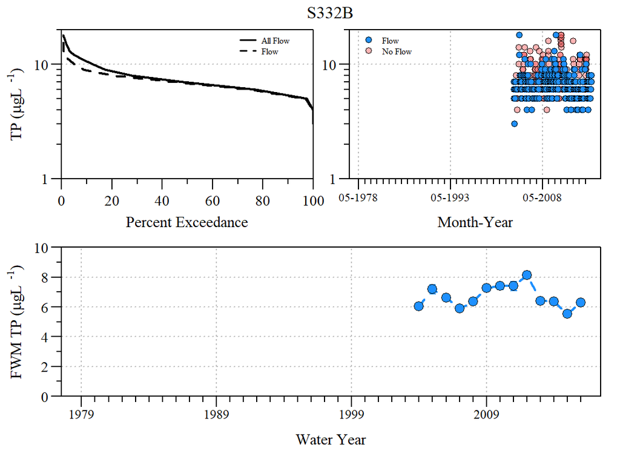

## S332C

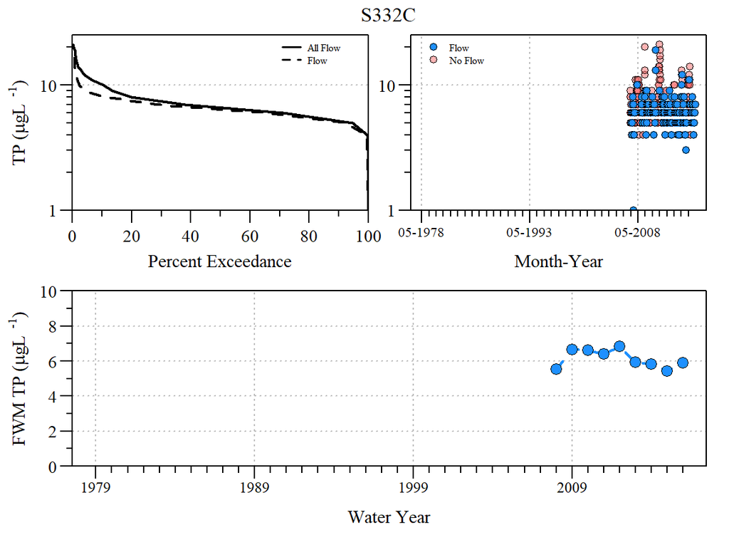

## S174

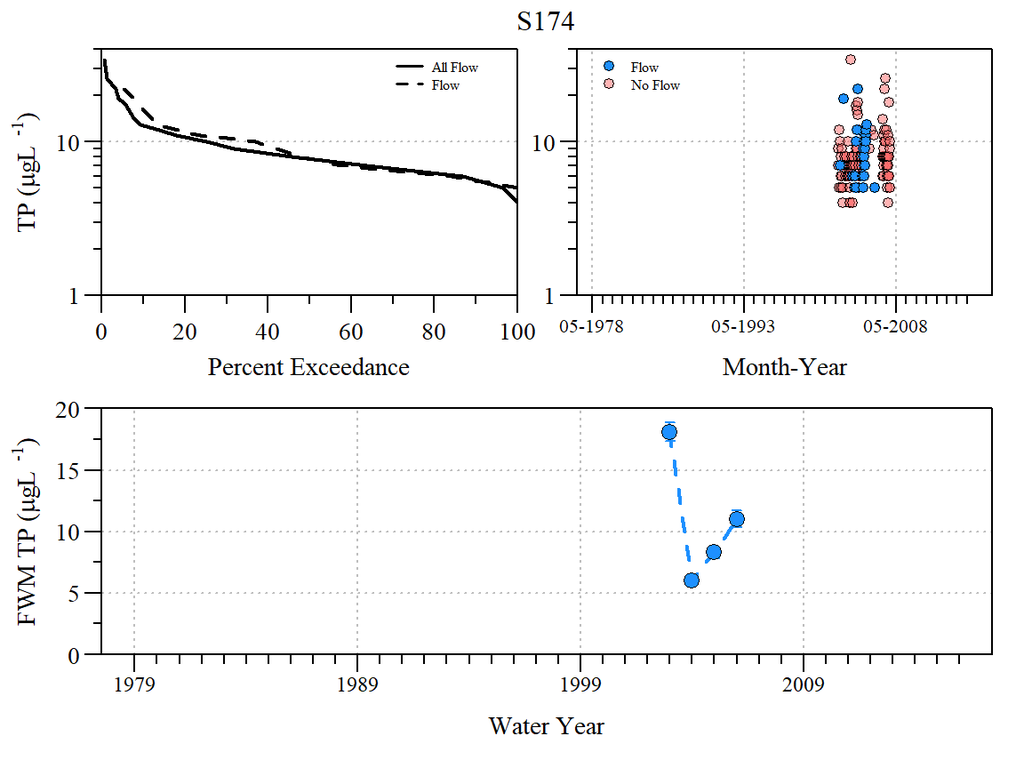

## S332D

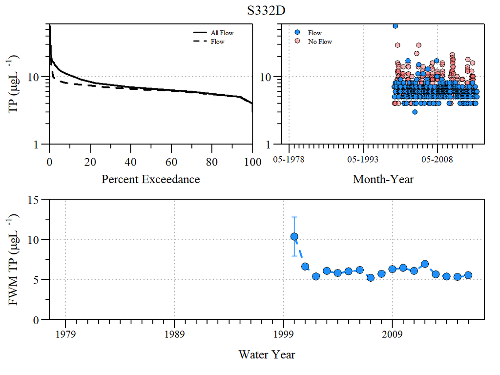

## S176

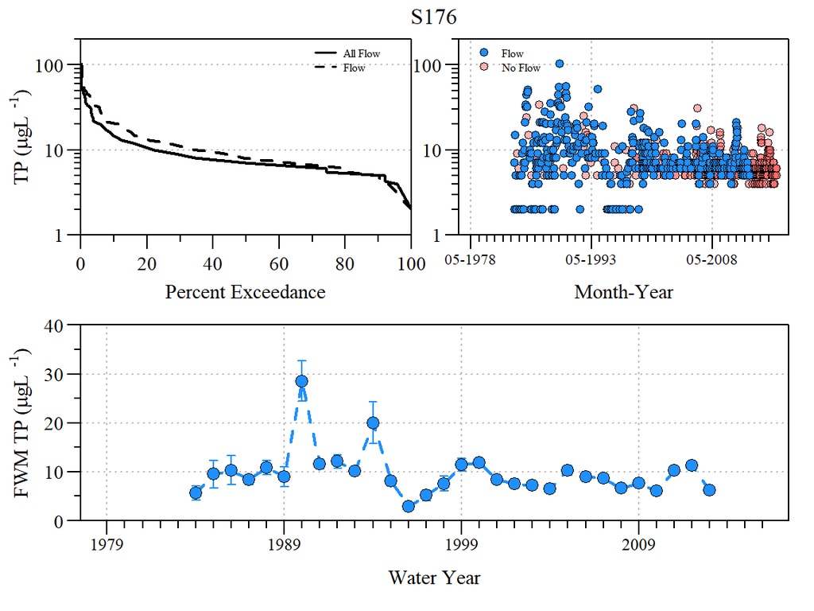

## S200

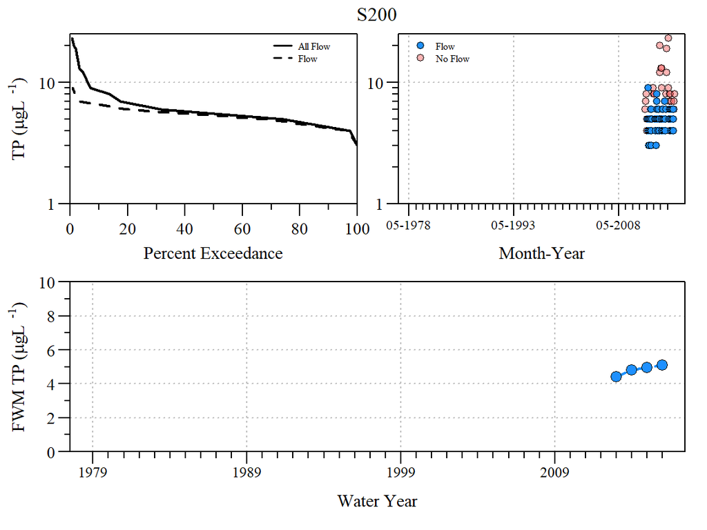

## S332

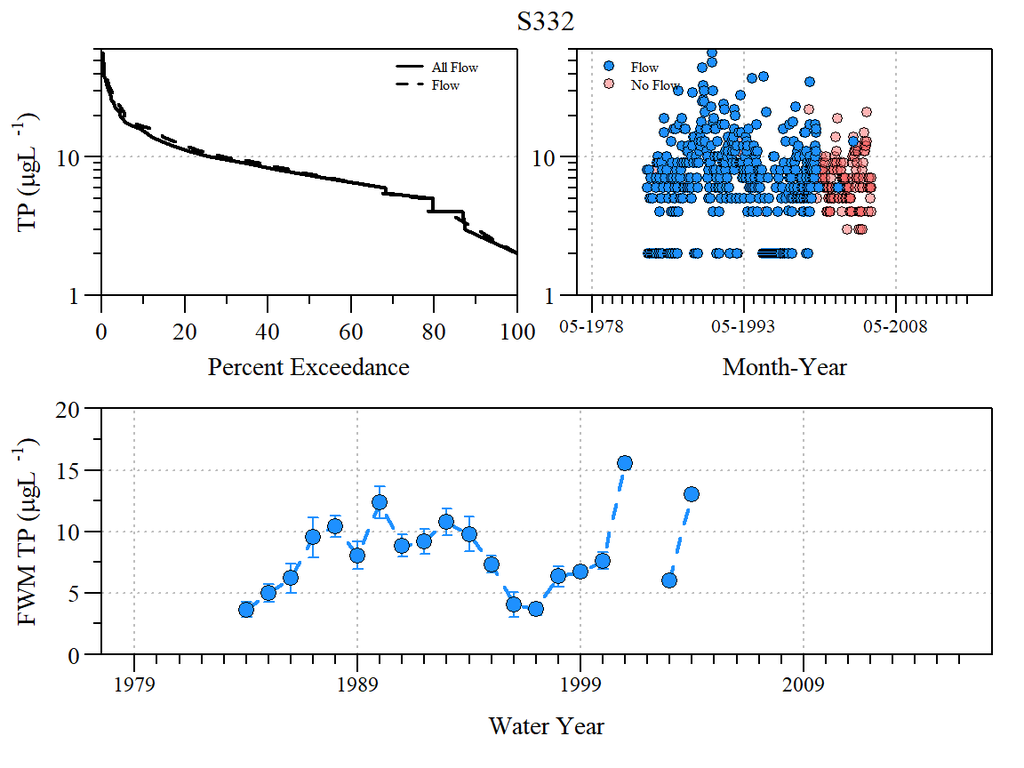

## S175

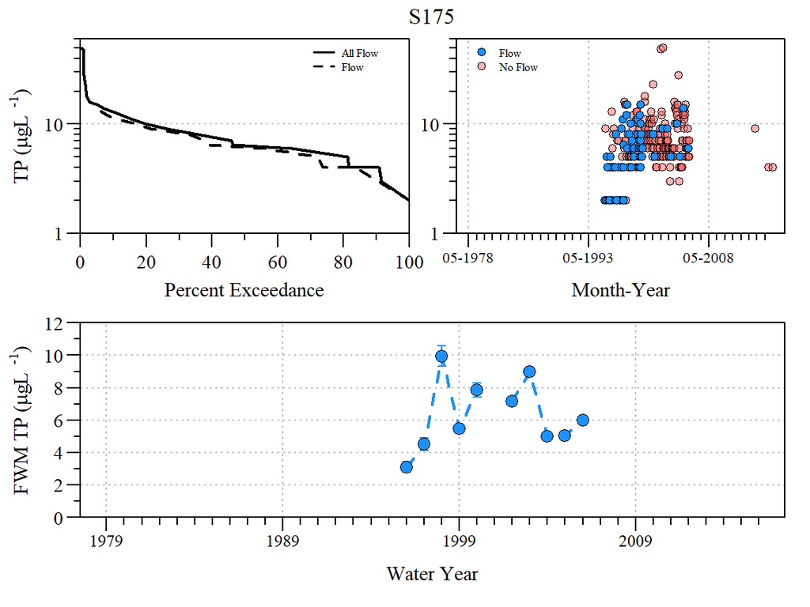

## S199

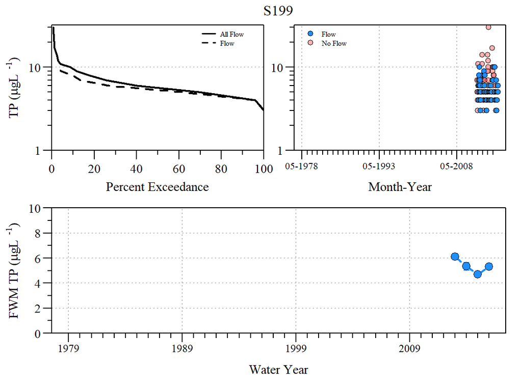

## S177

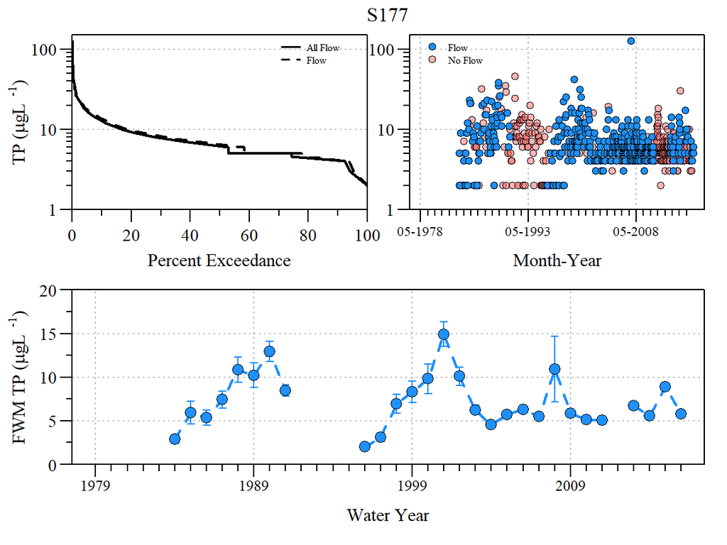

## S178

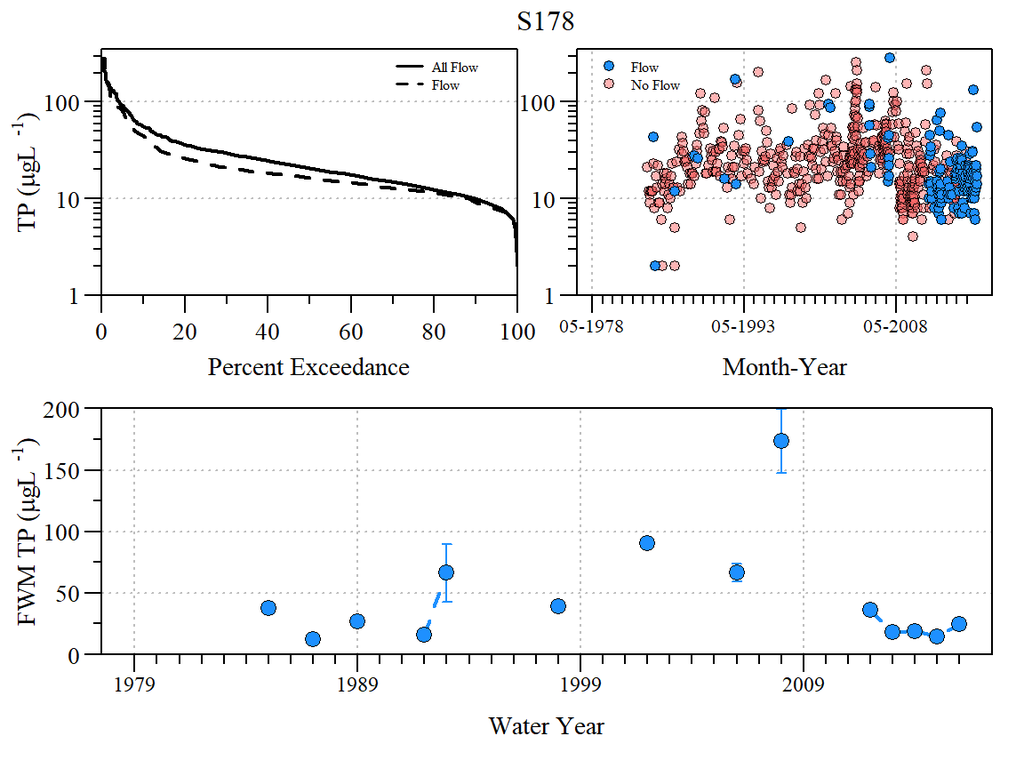